# PCAmatchR: Match Cases to Controls Based on Genotype Principal Components

Derek W. Brown, Timothy A. Myers, and Mitchell J. Machiela

7/30/2020

## Description

*PCAmatchR* matches cases to controls based on genotype principal components (PC). In order to produce more genetically similar matches, a weighted Mahalanobis distance metric ([Kidd et al. (1987)](https://www.sciencedirect.com/science/article/abs/pii/0031320387900665)) is used to determine matches. Weights are equal to the percent variance explained by each PC.

## Installation

The release version of *PCAmatchR* can be installed from CRAN:

```r
install.packages("PCAmatchR")
```

The development version of the *PCAmatchR* package can be installed from the GitHub repository by using the *devtools* package:

```r
devtools::install_github("machiela-lab/PCAmatchR")
```

*PCAmatchR* depends on the *optmatch* package which must be manually installed from CRAN:

```r
install.packages("optmatch")
```

Following installation, attach the *PCAmatchR* and *optmatch* packages with:

```r
library(PCAmatchR)
library(optmatch)
```

## Usage

Here we perform a hypothetical example of case-control matching using the Phase 3 data release of 1000 Genomes Project, which contains genotype data from 2,504 individuals from 26 distinct populations (available at https://www.cog-genomics.org/plink/2.0/resources).

### Available Data

Within *PCAmatchR*, we include sample data containing information about population, gender, and the first 20 principal components and eigenvalues calculated from 2,504 individuals in the Phase 3 data release of the 1000 Genomes Project. The example principal component analysis was conducted with PLINK using a set of ancestry informative SNPs ([Yu et al. (2008)](https://pubmed.ncbi.nlm.nih.gov/18596976/)). The data files are contained within:

- `PCs_1000G`, A sample dataset containing information about population, gender, and the first 20 principal components calculated from 2,504 individuals in the Phase 3 data release of the 1000 Genomes Project.
- `eigenvalues_1000G`, A sample dataset containing the first 20 eigenvalues calculated from 2,504 individuals in the Phase 3 data release of the 1000 Genomes Project.
- `eigenvalues_all_1000G`, A sample dataset containing all eigenvalues calculated from 2,504 individuals in the Phase 3 data release of the 1000 Genomes Project.

```r
# Load required packages
loadedPackages <- c("PCAmatchR", "optmatch")
invisible(lapply(loadedPackages, require, character.only = TRUE))

# Create PC data frame
pcs<- as.data.frame(PCs_1000G[,c(1,5:24)])

# Create eigenvalues vector
eigen_vals<- c(eigenvalues_1000G)$eigen_values

# Create full eigenvalues vector
all_eigen_vals<- c(eigenvalues_all_1000G)$eigen_values
```

### Case and Control Populations

For this example analysis, we select individuals from the ESN (Esan in Nigeria) population as cases (N=99), while all remaining samples are used as the control population (N=2,405):

```r
covariate_data<- as.data.frame(PCs_1000G[,1:4])
covariate_data$case <- ifelse(covariate_data$pop=="ESN", c(1), c(0))
```

### Case-Control Matching

Matching is performed using `match_maker`. Within this example, cases and controls are 1:2 matched on the first 20 PCs:

```r
match_maker_output<- match_maker(PC = pcs,
                                 eigen_value = eigen_vals,
                                 data = covariate_data,
                                 ids = c("sample"),
                                 case_control="case",
                                 num_controls = 2,
                                 eigen_sum = sum(all_eigen_vals))
```

Derived matches are contained within the `matches` object. The weighted Mahalanobis distance metric between case and control pairs is detailed within the `match_distance` variable:

```r
PCA_matches<- match_maker_output$matches
PCA_matches$match_distance
```

### Case-Control Matching Visualization

The distance between matches can be visualized using `plot_maker`:

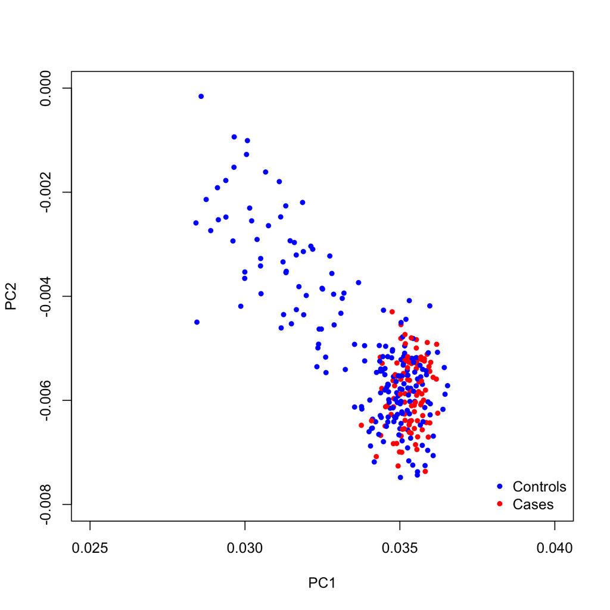

```r
plot_maker(data=match_maker_output,
           x_var="PC1",
           y_var="PC2",
           case_control="case",
           line=F,
           xlim = c(0.025,0.04),
           ylim = c(-0.008,0.00))
```

The function further allows for connections between matches:

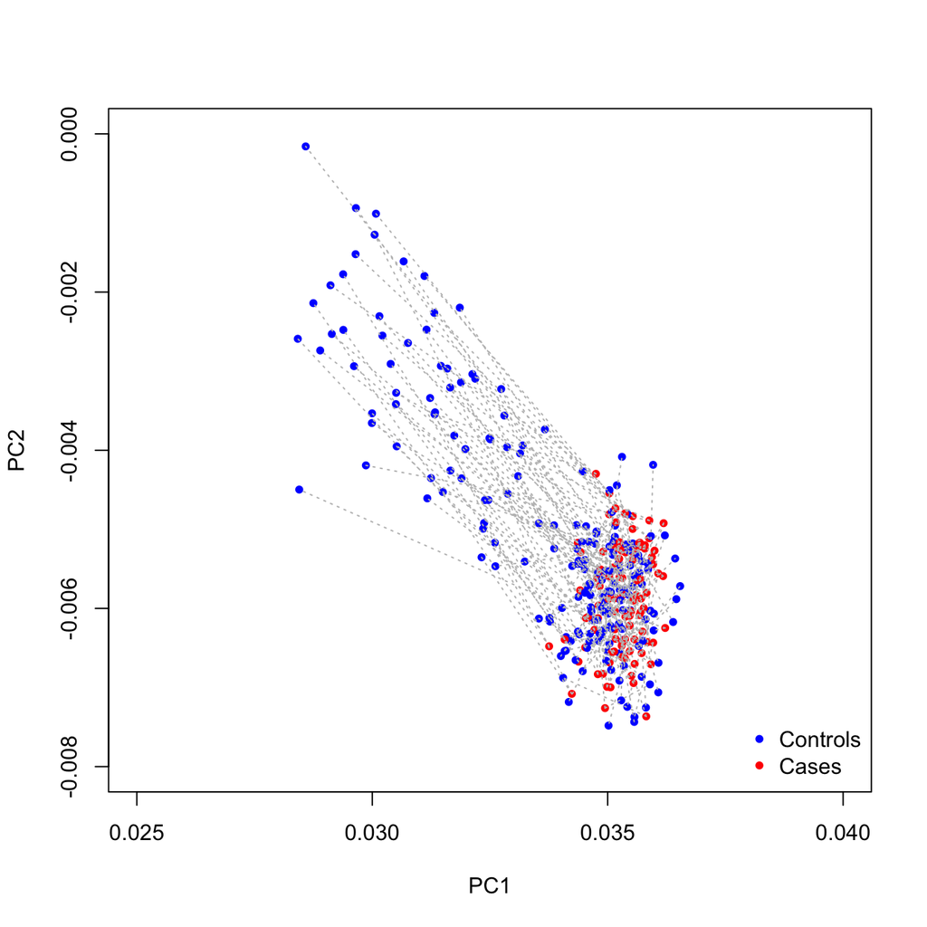

```r
plot_maker(data=match_maker_output,
           x_var="PC1",
           y_var="PC2",
           case_control="case",
           line=T,
           xlim = c(0.025,0.04),
           ylim = c(-0.008,0.00))
```